# Introduction

The objective of this project is to analyze data from a 2014 and 2016 survey that measures the general attitudes towards mental health and its occurrence within a tech company. I hope to inform this specific demographic of employees within the tech industry about what could be the strongest predictors of this illness that relays its occurrence.

Throughout my tutorial, I will be trying to find any correlations and trends between different mental health benefits and consequences, the availability of care options depending on company type and so much more. Within my mining, I hope to protray results that demonstrate how such attitudes may be formed.

# Data Collection

I will be collecting and scraping data from Kaggle (which is a data science company full of public datasets) found specifically at https://www.kaggle.com/datasets/osmi/mental-health-in-tech-survey?resource=download & https://www.kaggle.com/datasets/osmi/mental-health-in-tech-2016 and formatting it into a dataframe so that it is easy to both visualize and alter for exploratory analysis. The datasets have been downlaoded into a CSV or Comma Separated Value file. I will be using different Python3 libraries to acheive this such as numpy, pandas, and more.

```python
! pip install geopy
```

```python
import pandas as pd
import numpy as np
import folium
import seaborn as sb
import matplotlib.pyplot as plt
from geopy import geocoders
from geopy.geocoders import Nominatim

survey_2014 = pd.read_csv("survey.csv")
survey_2016 = pd.read_csv("mental-health-in-tech-2016.csv")
survey_2014.head()
```

|  | Timestamp | Age | Gender | Country | state | self_employed | family_history | treatment | work_interfere | no_employees | ... | leave | mental_health_consequence | phys_health_consequence | coworkers | supervisor | mental_health_interview | phys_health_interview | mental_vs_physical | obs_consequence | comments |
| --- | --- | --- | --- | --- | --- | --- | --- | --- | --- | --- | --- | --- | --- | --- | --- | --- | --- | --- | --- | --- | --- |
| 0 | 2014-08-27 11:29:31 | 37 | Female | United States | IL | NaN | No | Yes | Often | 6-25 | ... | Somewhat easy | No | No | Some of them | Yes | No | Maybe | Yes | No | NaN |
| 1 | 2014-08-27 11:29:37 | 44 | M | United States | IN | NaN | No | No | Rarely | More than 1000 | ... | Don't know | Maybe | No | No | No | No | No | Don't know | No | NaN |
| 2 | 2014-08-27 11:29:44 | 32 | Male | Canada | NaN | NaN | No | No | Rarely | 6-25 | ... | Somewhat difficult | No | No | Yes | Yes | Yes | Yes | No | No | NaN |
| 3 | 2014-08-27 11:29:46 | 31 | Male | United Kingdom | NaN | NaN | Yes | Yes | Often | 26-100 | ... | Somewhat difficult | Yes | Yes | Some of them | No | Maybe | Maybe | No | Yes | NaN |
| 4 | 2014-08-27 11:30:22 | 31 | Male | United States | TX | NaN | No | No | Never | 100-500 | ... | Don't know | No | No | Some of them | Yes | Yes | Yes | Don't know | No | NaN |

5 rows × 27 columns

```python
print(list(survey_2014.columns))
```

```
['Timestamp', 'Age', 'Gender', 'Country', 'state', 'self_employed', 'family_history', 'treatment', 'work_interfere', 'no_employees', 'remote_work', 'tech_company', 'benefits', 'care_options', 'wellness_program', 'seek_help', 'anonymity', 'leave', 'mental_health_consequence', 'phys_health_consequence…
```

I used the pandas.read_csv function to read in both of the csv files and stored them into separate Dataframes. I have displayed the head of the Dataframe from the 2014 survey and have displayed its 27 columns. Some columns are not self-explanatory, so I will list out the survey questions that pertains to column names as provided from the website.

- mental_health_consequence: Do you think that discussing a mental health issue with your employer would have negative consequences?
- phys_health_consequence: Do you think that discussing a physical health issue with your employer would have negative consequences?
- coworkers: Would you be willing to discuss a mental health issue with your coworkers?
- supervisor: Would you be willing to discuss a mental health issue with your direct supervisor(s)?
- mental_health_interview: Would you bring up a mental health issue with a potential employer in an interview?
- phys_health_interview: Would you bring up a physical health issue with a potential employer in an interview?

```python
survey_2016.head()
```

|  | Are you self-employed? | How many employees does your company or organization have? | Is your employer primarily a tech company/organization? | Is your primary role within your company related to tech/IT? | Does your employer provide mental health benefits as part of healthcare coverage? | Do you know the options for mental health care available under your employer-provided coverage? | Has your employer ever formally discussed mental health (for example, as part of a wellness campaign or other official communication)? | Does your employer offer resources to learn more about mental health concerns and options for seeking help? | Is your anonymity protected if you choose to take advantage of mental health or substance abuse treatment resources provided by your employer? | If a mental health issue prompted you to request a medical leave from work, asking for that leave would be: | ... | If you have a mental health issue, do you feel that it interferes with your work when being treated effectively? | If you have a mental health issue, do you feel that it interferes with your work when NOT being treated effectively? | What is your age? | What is your gender? | What country do you live in? | What US state or territory do you live in? | What country do you work in? | What US state or territory do you work in? | Which of the following best describes your work position? | Do you work remotely? |
| --- | --- | --- | --- | --- | --- | --- | --- | --- | --- | --- | --- | --- | --- | --- | --- | --- | --- | --- | --- | --- | --- |
| 0 | 0 | 26-100 | 1.0 | NaN | Not eligible for coverage / N/A | NaN | No | No | I don't know | Very easy | ... | Not applicable to me | Not applicable to me | 39 | Male | United Kingdom | NaN | United Kingdom | NaN | Back-end Developer | Sometimes |
| 1 | 0 | 6-25 | 1.0 | NaN | No | Yes | Yes | Yes | Yes | Somewhat easy | ... | Rarely | Sometimes | 29 | male | United States of America | Illinois | United States of America | Illinois | Back-end Developer\|Front-end Developer | Never |
| 2 | 0 | 6-25 | 1.0 | NaN | No | NaN | No | No | I don't know | Neither easy nor difficult | ... | Not applicable to me | Not applicable to me | 38 | Male | United Kingdom | NaN | United Kingdom | NaN | Back-end Developer | Always |
| 3 | 1 | NaN | NaN | NaN | NaN | NaN | NaN | NaN | NaN | NaN | ... | Sometimes | Sometimes | 43 | male | United Kingdom | NaN | United Kingdom | NaN | Supervisor/Team Lead | Sometimes |
| 4 | 0 | 6-25 | 0.0 | 1.0 | Yes | Yes | No | No | No | Neither easy nor difficult | ... | Sometimes | Sometimes | 43 | Female | United States of America | Illinois | United States of America | Illinois | Executive Leadership\|Supervisor/Team Lead\|Dev ... | Sometimes |

5 rows × 63 columns

This is the head of the second survey displayed; its columns are the actual survey questions which make it easier to interpret and are self-explanatory.

# Data Tidying and Management

In this phase of The Data Science Pipeline, I will be tidying up the data to make it more readable and strengthen the organization of my dataframes. This will make the exploratory anaylsis easier because I have better navigation of all of the information.

```python
survey_2014.drop(["Timestamp", "comments"], axis = 1, inplace = True) # get rid of unnecessary columns
survey_2014["Gender"] = np.where((survey_2014["Gender"] == "Male") | (survey_2014["Gender"] == "m") | (survey_2014["Gender"] == "male")
                                 , "M", survey_2014["Gender"])
survey_2014["Gender"] = np.where((survey_2014["Gender"] == "Female") | (survey_2014["Gender"] == "f") | (survey_2014["Gender"] == "female")
                                 , "F", survey_2014["Gender"])
survey_2014 = survey_2014.rename(columns=str.lower)
survey_2014.head()
```

|  | age | gender | country | state | self_employed | family_history | treatment | work_interfere | no_employees | remote_work | ... | anonymity | leave | mental_health_consequence | phys_health_consequence | coworkers | supervisor | mental_health_interview | phys_health_interview | mental_vs_physical | obs_consequence |
| --- | --- | --- | --- | --- | --- | --- | --- | --- | --- | --- | --- | --- | --- | --- | --- | --- | --- | --- | --- | --- | --- |
| 0 | 37 | F | United States | IL | NaN | No | Yes | Often | 6-25 | No | ... | Yes | Somewhat easy | No | No | Some of them | Yes | No | Maybe | Yes | No |
| 1 | 44 | M | United States | IN | NaN | No | No | Rarely | More than 1000 | No | ... | Don't know | Don't know | Maybe | No | No | No | No | No | Don't know | No |
| 2 | 32 | M | Canada | NaN | NaN | No | No | Rarely | 6-25 | No | ... | Don't know | Somewhat difficult | No | No | Yes | Yes | Yes | Yes | No | No |
| 3 | 31 | M | United Kingdom | NaN | NaN | Yes | Yes | Often | 26-100 | No | ... | No | Somewhat difficult | Yes | Yes | Some of them | No | Maybe | Maybe | No | Yes |
| 4 | 31 | M | United States | TX | NaN | No | No | Never | 100-500 | Yes | ... | Don't know | Don't know | No | No | Some of them | Yes | Yes | Yes | Don't know | No |

5 rows × 25 columns

Although the column names for the 2016 survey were easy to interpret because they were questions, to further tidy this data I will rename these columns to make the dataframe more concise. The list of the columns before tidying is below:

```python
for col in survey_2016.columns:
    print(col)
```

```
Are you self-employed?
How many employees does your company or organization have?
Is your employer primarily a tech company/organization?
Is your primary role within your company related to tech/IT?
Does your employer provide mental health benefits as part of healthcare coverage?
Do you know the options for mental health care available under your employer-provided coverage?
Has your employer ever formally discussed mental health (for example, as part of a wellness campaign or other official communication)?
Does your employer offer resources to learn more about mental health concerns and options for seeking help?
Is your anonymity protected if you choose to take advantage of mental health or substance abuse treatment resources provided by your employer?
If a mental health issue prompted you to request a medical leave from work, asking for that leave would be:
Do you think that discussing a mental health disorder with your employer would have negative consequences?
Do you think that discussing a physical health issue with your employer would have negative consequences?
Would you feel comfortable discussing a mental health disorder with your coworkers?
Would you feel comfortable discussing a mental health disorder with your direct supervisor(s)?
Do you feel that your employer takes mental health as seriously as physical health?
Have you heard of or observed negative consequences for co-workers who have been open about mental health issues in your workplace?
Do you have medical coverage (private insurance or state-provided) which includes treatment of  mental health issues?
Do you know local or online resources to seek help for a mental health disorder?
If you have been diagnosed or treated for a mental health disorder, do you ever reveal this to clients or business contacts?
If you have revealed a mental health issue to a client or business contact, do you believe this has impacted you negatively?
If you have been diagnosed or treated for a mental health disorder, do you ever reveal this to coworkers or employees?
If you have revealed a mental health issue to a coworker or employee, do you believe this has impacted you negatively?
Do you believe your productivity is ever affected by a mental health issue?
If yes, what percentage of your work time (time performing primary or secondary job functions) is affected by a mental health issue?
Do you have previous employers?
Have your previous employers provided mental health benefits?
Were you aware of the options for mental health care provided by your previous employers?
Did your previous employers ever formally discuss mental health (as part of a wellness campaign or other official communication)?
Did your previous employers provide resources to learn more about mental health issues and how to seek help?
Was your anonymity protected if you chose to take advantage of mental health or substance abuse treatment resources with previous employers?
Do you think that discussing a mental health disorder with previous employers would have negative consequences?
Do you think that discussing a physical health issue with previous employers would have negative consequences?
Would you have been willing to discuss a mental health issue with your previous co-workers?
Would you have been willing to discuss a mental health issue with your direct supervisor(s)?
Did you feel that your previous employers took mental health as seriously as physical health?
Did you hear of or observe negative consequences for co-workers with mental health issues in your previous workplaces?
Would you be willing to bring up a physical health issue with a potential employer in an interview?
Why or why not?
Would you bring up a mental health issue with a potential employer in an interview?
Why or why not?.1
```

[output cut: 8 more lines]

```
If yes, what condition(s) have you been diagnosed with?
If maybe, what condition(s) do you believe you have?
Have you been diagnosed with a mental health condition by a medical professional?
If so, what condition(s) were you diagnosed with?
Have you ever sought treatment for a mental health issue from a mental health professional?
If you have a mental health issue, do you feel that it interferes with your work when being treated effectively?
If you have a mental health issue, do you feel that it interferes with your work when NOT being treated effectively?
What is your age?
What is your gender?
What country do you live in?
What US state or territory do you live in?
What country do you work in?
What US state or territory do you work in?
Which of the following best describes your work position?
Do you work remotely?
```

```python
survey_2016.rename(columns = {"Are you self-employed?":"self_employed", "How many employees does your company or organization have?"
                              :"no_employees", "Is your employer primarily a tech company/organization?":"tech_company", "Is your primary role within your company related to tech/IT?"
                              :"primary_role", "Does your employer provide mental health benefits as part of healthcare coverage?":
                              "benefits", "Do you know the options for mental health care available under your employer-provided coverage?":"care_options",
                              "Has your employer ever formally discussed mental health (for example, as part of a wellness campaign or other official communication)?"
                              :"wellness_program", "Does your employer offer resources to learn more about mental health concerns and options for seeking help?"
                              :"seek_help", "Is your anonymity protected if you choose to take advantage of mental health or substance abuse treatment resources provided by your employer?"
                              :"anonymity", "If a mental health issue prompted you to request a medical leave from work, asking for that leave would be:":
                              "leave", "Do you think that discussing a mental health disorder with your employer would have negative consequences?":
                              "mental_health_consequence", "Do you think that discussing a physical health issue with your employer would have negative consequences?"
                              : "phys_health_consequence", "Would you feel comfortable discussing a mental health disorder with your coworkers?":"coworkers",
                              "Would you feel comfortable discussing a mental health disorder with your direct supervisor(s)?":"supervisor",
                              "Do you feel that your employer takes mental health as seriously as physical health?":"mental_vs_physical",
                              "Have you heard of or observed negative consequences for co-workers who have been open about mental health issues in your workplace?"
                              :"obs_consequence", "If you have been diagnosed or treated for a mental health disorder, do you ever reveal this to clients or business contacts?"
                              :"client_reveal", "If you have revealed a mental health issue to a client or business contact, do you believe this has impacted you negatively?"
                              :"client_impact", "If you have been diagnosed or treated for a mental health disorder, do you ever reveal this to coworkers or employees?"
                              :"coworker_reveal", "If you have revealed a mental health issue to a coworker or employee, do you believe this has impacted you negatively?"
                              :"coworker_impact", "Do you believe your productivity is ever affected by a mental health issue?":"productivity",
                              "If yes, what percentage of your work time (time performing primary or secondary job functions) is affected by a mental health issue?"
                              :"productivity_prt", "Do you have previous employers?":"prev_employer", "Have your previous employers provided mental health benefits?"
                              :"prev_benefits", "Were you aware of the options for mental health care provided by your previous employers?":
                              "prev_care_options", "Did your previous employers ever formally discuss mental health (as part of a wellness campaign or other official communication)?"
                              :"prev_wellness_program", "Did your previous employers provide resources to learn more about mental health issues and how to seek help?"
                              :"prev_seek_help", "Was your anonymity protected if you chose to take advantage of mental health or substance abuse treatment resources with previous employers?"
                              :"prev_anonymity", "Do you think that discussing a mental health disorder with previous employers would have negative consequences?":
                              "prev_mental_consequence", "Do you think that discussing a physical health issue with previous employers would have negative consequences?"
                              :"prev_phys_consequence", "Would you have been willing to discuss a mental health issue with your previous co-workers?"
                              :"prev_coworkers", "Would you have been willing to discuss a mental health issue with your direct supervisor(s)?":"prev_supervisor",
                              "Did you feel that your previous employers took mental health as seriously as physical health?":"prev_menvsphys",
                              "Did you hear of or observe negative consequences for co-workers with mental health issues in your previous workplaces?":
                              "prev_obs_consequence", "Would you be willing to bring up a physical health issue with a potential employer in an interview?"
                              :"phys_interview_reveal", "Why or why not?":"phys_interview_impact", "Would you bring up a mental health issue with a potential employer in an interview?"
                              :"mental_interview_reveal", "Why or why not?.1":"mental_interview_impact", "Do you feel that being identified as a person with a mental health issue would hurt your career?"
                              :"career_impact", "Do you think that team members/co-workers would view you more negatively if they knew you suffered from a mental health issue?"
                              :"coworker_opinion", "How willing would you be to share with friends and family that you have a mental illness?":
                              "share_illness", "Have you observed or experienced an unsupportive or badly handled response to a mental health issue in your current or previous workplace?"
                              :"obs_bad_response", "Have your observations of how another individual who discussed a mental health disorder made you less likely to reveal a mental health issue yourself in your current workplace?"
                              :"personal_reveal", "Do you have a family history of mental illness?":"family_history",
                              "Have you had a mental health disorder in the past?":"past_disorder", "Do you currently have a mental health disorder?"
                              :"current_disorder", "If yes, what condition(s) have you been diagnosed with?":"current_diagnosis",
                              "If maybe, what condition(s) do you believe you have?":"believed_diagnosis", "Have you been diagnosed with a mental health condition by a medical professional?"
                              :"doctor_diagnosis", "If so, what condition(s) were you diagnosed with?":"doctor_condition",
                              "Have you ever sought treatment for a mental health issue from a mental health professional?":"treatment",
                              "If you have a mental health issue, do you feel that it interferes with your work when being treated effectively?":
                              "eff_treatment_productivity", "If you have a mental health issue, do you feel that it interferes with your work when NOT being treated effectively?"
                              :"noteff_treatment_productivity", "What is your age?":"age", "What is your gender?":"gender",
                              "What country do you live in?":"live_country", "What US state or territory do you live in?":"live_state",
                              "What country do you work in?":"work_country", "What US state or territory do you work in?":"work_state",
                              "Which of the following best describes your work position?":"work_position", "Do you work remotely?":
                              "remote_work", "Do you have medical coverage (private insurance or state-provided) which includes treatment of \xa0mental health issues?"
                             :"coverage", "Do you know local or online resources to seek help for a mental health disorder?":
                             "know_resources"}, inplace = True)
print(list(survey_2016.columns))
```

```
['self_employed', 'no_employees', 'tech_company', 'primary_role', 'benefits', 'care_options', 'wellness_program', 'seek_help', 'anonymity', 'leave', 'mental_health_consequence', 'phys_health_consequence', 'coworkers', 'supervisor', 'mental_vs_physical', 'obs_consequence', 'coverage', 'know_resources…
```

This is the condensed list of columns afterwards. Now that the column names are easier to work with, I can further manipulate and tidy the data as needed for analysis.

```python
survey_2016["gender"] = np.where((survey_2016["gender"] == "Male") | (survey_2016["gender"] == "m") | (survey_2016["gender"] == "male")
                                 | (survey_2016["gender"] == "Male ") | (survey_2016["gender"] == "MALE")
                                 , "M", survey_2016["gender"])
survey_2016["gender"] = np.where((survey_2016["gender"] == "Female") | (survey_2016["gender"] == "f") | (survey_2016["gender"] == "female")
                                | (survey_2016["gender"] == "Female "), "F", survey_2016["gender"])
survey_2016.head()
```

|  | self_employed | no_employees | tech_company | primary_role | benefits | care_options | wellness_program | seek_help | anonymity | leave | ... | eff_treatment_productivity | noteff_treatment_productivity | age | gender | live_country | live_state | work_country | work_state | work_position | remote_work |
| --- | --- | --- | --- | --- | --- | --- | --- | --- | --- | --- | --- | --- | --- | --- | --- | --- | --- | --- | --- | --- | --- |
| 0 | 0 | 26-100 | 1.0 | NaN | Not eligible for coverage / N/A | NaN | No | No | I don't know | Very easy | ... | Not applicable to me | Not applicable to me | 39 | M | United Kingdom | NaN | United Kingdom | NaN | Back-end Developer | Sometimes |
| 1 | 0 | 6-25 | 1.0 | NaN | No | Yes | Yes | Yes | Yes | Somewhat easy | ... | Rarely | Sometimes | 29 | M | United States of America | Illinois | United States of America | Illinois | Back-end Developer\|Front-end Developer | Never |
| 2 | 0 | 6-25 | 1.0 | NaN | No | NaN | No | No | I don't know | Neither easy nor difficult | ... | Not applicable to me | Not applicable to me | 38 | M | United Kingdom | NaN | United Kingdom | NaN | Back-end Developer | Always |
| 3 | 1 | NaN | NaN | NaN | NaN | NaN | NaN | NaN | NaN | NaN | ... | Sometimes | Sometimes | 43 | M | United Kingdom | NaN | United Kingdom | NaN | Supervisor/Team Lead | Sometimes |
| 4 | 0 | 6-25 | 0.0 | 1.0 | Yes | Yes | No | No | No | Neither easy nor difficult | ... | Sometimes | Sometimes | 43 | F | United States of America | Illinois | United States of America | Illinois | Executive Leadership\|Supervisor/Team Lead\|Dev ... | Sometimes |

5 rows × 63 columns

Similar to the 2014 data, I simplified the gender column to recognize entries that pertained to both the M and F gender. I have tidied my data to my liking and am now ready to start my analysis on these different factors.

# Exploratory Data Analysis

In this phase of The Data Science Pipeline, I will plot my data and exploit trends along different variables from both of the surveys. I will be investigating these datasets in hopes of observing patterns, outliers and understanding the data to form hypotheses. Most of the data collected within these datasets are not of numerical value, so I will be looking at the frequency of responses moreso than manipulating any numbers (operations such as max).

I will be exploring the data from the surveys seperately and then ultimate look at their trends together. Below is my exploration of the 2014 data:

# **2014**

## **Graphing Frequency of Difficulty of Asking for Leave based on Type of Company**

| leave | tech_company | 0 |
| --- | --- | --- |
| Don't know | No | 107 |
| Somewhat difficult | No | 28 |
| Somewhat easy | No | 47 |
| Very difficult | No | 19 |
| Very easy | No | 27 |
| Don't know | Yes | 456 |
| Somewhat difficult | Yes | 98 |
| Somewhat easy | Yes | 219 |
| Very difficult | Yes | 79 |
| Very easy | Yes | 179 |

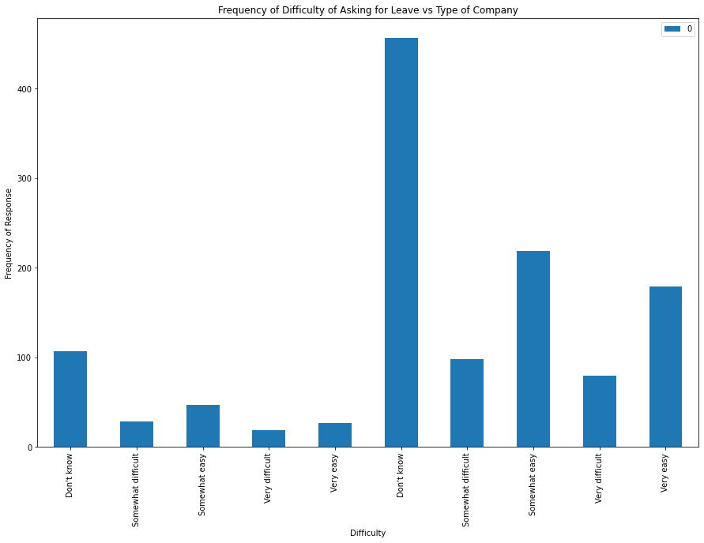

```python
survey_2014.value_counts(["tech_company", "leave"]).reset_index().sort_values(["tech_company", "leave"]).set_index('leave').plot(kind = 'bar', figsize = (15,10))

plt.title("Frequency of Difficulty of Asking for Leave vs Type of Company")
plt.xlabel("Difficulty")
plt.ylabel("Frequency of Response")
survey_2014.value_counts(["tech_company", "leave"]).reset_index().sort_values(["tech_company", "leave"]).set_index('leave')
```

Up above, I have graphed the frequency of survey responses to the survey question: "How easy is it for you to take medical leave for a mental health condition?" based on if the company was in the tech industry or not. As similar to the small data table above it, the first 5 bars of the graph pertain to if the company was not tech-related. Based on these results, not many employees working for a tech company are sure of the difficulty (most likely because they have not done so), yet most responses say that it is somewhat easy to ask. The frequency of the easy responses within a tech company are larger than companies that aren't.

## **Correlation Between Anonymity and Supervisor Interaction**

Does increased anonymity make it easier to talk to supervisor about mental health issues?

| supervisor | anonymity | 0 |
| --- | --- | --- |
| No | Don't know | 275 |
| Some of them | Don't know | 246 |
| Yes | Don't know | 298 |
| No | No | 38 |
| Some of them | No | 13 |
| Yes | No | 14 |
| No | Yes | 80 |
| Some of them | Yes | 91 |
| Yes | Yes | 204 |

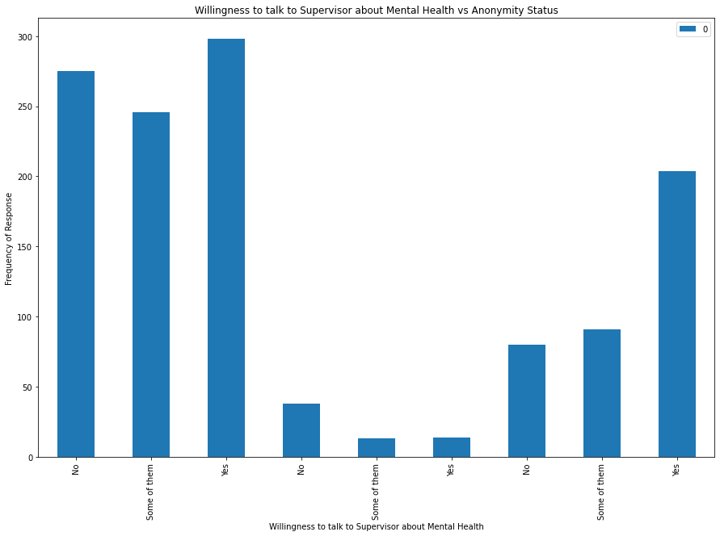

```python
survey_2014.value_counts(["anonymity", "supervisor"]).reset_index().sort_values(["anonymity", "supervisor"]).set_index('supervisor').plot(kind = 'bar', figsize = (15,10))
plt.title("Willingness to talk to Supervisor about Mental Health vs Anonymity Status")
plt.xlabel("Willingness to talk to Supervisor about Mental Health")
plt.ylabel("Frequency of Response")
survey_2014.value_counts(["anonymity", "supervisor"]).reset_index().sort_values(["anonymity", "supervisor"]).set_index('supervisor')
```

Again, we are comparing the frequency of these responses to see if the protection of being anonymous when receiving treatment resources affects whether employees feel comfortable sharing mental health issues with their supervisors. In accordance to the responses of "Don't Know", "No", and "Yes" respectively, each section of 3 bars corresponds to this answer about whether an individual's anonymity is protected at their company. Even though workers are unware of their protection, the highest frequency recorded of 298 responses went to "Yes". As expected, the values are a lot lower when it is known that their information does not remain anonymous. Is oblivion a better state in this case?

## **Geographic Location as an Indicator of Mental Health**

```python
latitude = 37.0902
longitude = -95.7129
US_map = folium.Map(location=[latitude, longitude], zoom_start=4.5)

for index, row in (survey_2014[survey_2014['country'] == "United States"]).iterrows():
    if row["family_history"] == "Yes":
        state = row["state"]
        geolocator = Nominatim(user_agent="MyApp")
        location = geolocator.geocode(state)
        folium.Marker(location=[location.latitude, location.longitude],
                icon=folium.Icon(color='blue')).add_to(US_map)
US_map
```

Make this Notebook Trusted to load map: File -> Trust Notebook

[interactive chart not shown]

As we can see with the graph of the United States, individuals who lived along the East Coast more heavily reported having a family history of mental illness. Surprisingly, there was not a single marker within the state of California. This is shocking as California is both heavily populated and a popular place for tech companies.

# **2016**

## **Productivity of Effective vs Non-Effective Treatment of Mental Health**

```
                              productivity_prt   0
noteff_treatment_productivity
Not applicable to me                     1-25%  17
Often                                    1-25%  31
Rarely                                   1-25%   4
Sometimes                                1-25%  40
Not applicable to me                    26-50%   3
Often                                   26-50%  42
Rarely                                  26-50%   1
Sometimes                               26-50%  26
Not applicable to me                    51-75%   2
Often                                   51-75%  22
Sometimes                               51-75%   2
Never                                  76-100%   1
Not applicable to me                   76-100%   1
Often                                  76-100%  10
Rarely                                 76-100%   1
Sometimes                              76-100%   1
                           productivity_prt   0
eff_treatment_productivity
Never                                 1-25%   7
Not applicable to me                  1-25%  24
Rarely                                1-25%  34
Sometimes                             1-25%  27
Never                                26-50%   1
Not applicable to me                 26-50%  13
Often                                26-50%   6
Rarely                               26-50%  17
Sometimes                            26-50%  35
Never                                51-75%   1
Not applicable to me                 51-75%   2
Often                                51-75%   9
Rarely                               51-75%   4
Sometimes                            51-75%  10
Never                               76-100%   2
Not applicable to me                76-100%   1
Often                               76-100%   5
Sometimes                           76-100%   6
```

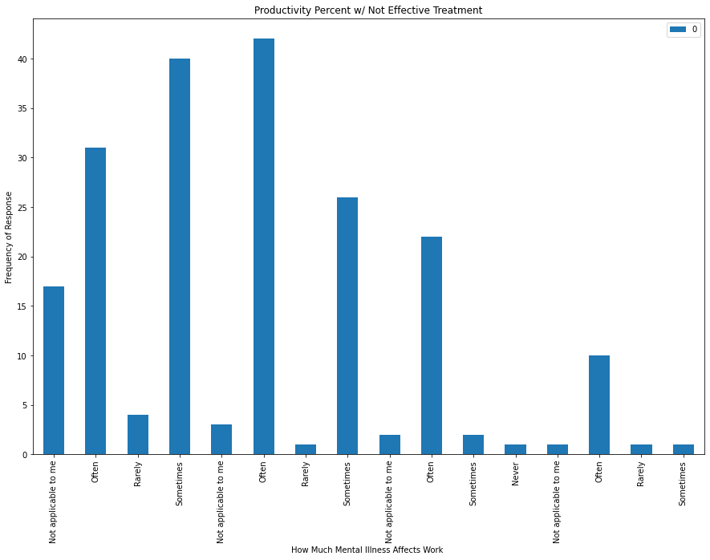

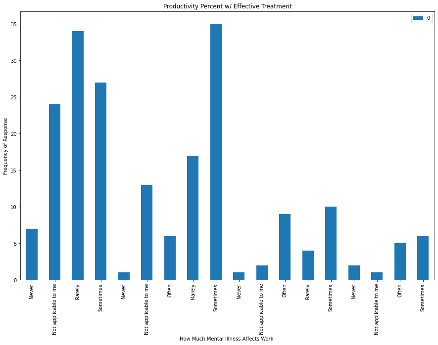

```python
# Not-Effective
survey_2016.value_counts(["productivity_prt", "noteff_treatment_productivity"]).reset_index().sort_values(["productivity_prt", "noteff_treatment_productivity"]).set_index('noteff_treatment_productivity').plot(kind = 'bar', figsize = (15,10))
plt.title("Productivity Percent w/ Not Effective Treatment")
plt.xlabel("How Much Mental Illness Affects Work ")
plt.ylabel("Frequency of Response")
print(survey_2016.value_counts(["productivity_prt", "noteff_treatment_productivity"]).reset_index().sort_values(["productivity_prt", "noteff_treatment_productivity"]).set_index('noteff_treatment_productivity'))

# Effective
survey_2016.value_counts(["productivity_prt", "eff_treatment_productivity"]).reset_index().sort_values(["productivity_prt", "eff_treatment_productivity"]).set_index('eff_treatment_productivity').plot(kind = 'bar', figsize = (15,10))
plt.title("Productivity Percent w/ Effective Treatment")
plt.xlabel("How Much Mental Illness Affects Work ")
plt.ylabel("Frequency of Response")
print(survey_2016.value_counts(["productivity_prt", "eff_treatment_productivity"]).reset_index().sort_values(["productivity_prt", "eff_treatment_productivity"]).set_index('eff_treatment_productivity'))
```

## **Correlation of Medical Diagnosis and Perceived Negative Career Impact**

```
                           doctor_diagnosis    0
career_impact
Maybe                                    No  337
Maybe                                   Yes  251
No, I don't think it would               No   76
No, I don't think it would              Yes   71
No, it has not                           No    4
No, it has not                          Yes   26
Yes, I think it would                    No  273
Yes, I think it would                   Yes  290
Yes, it has                              No   27
Yes, it has                             Yes   78
```

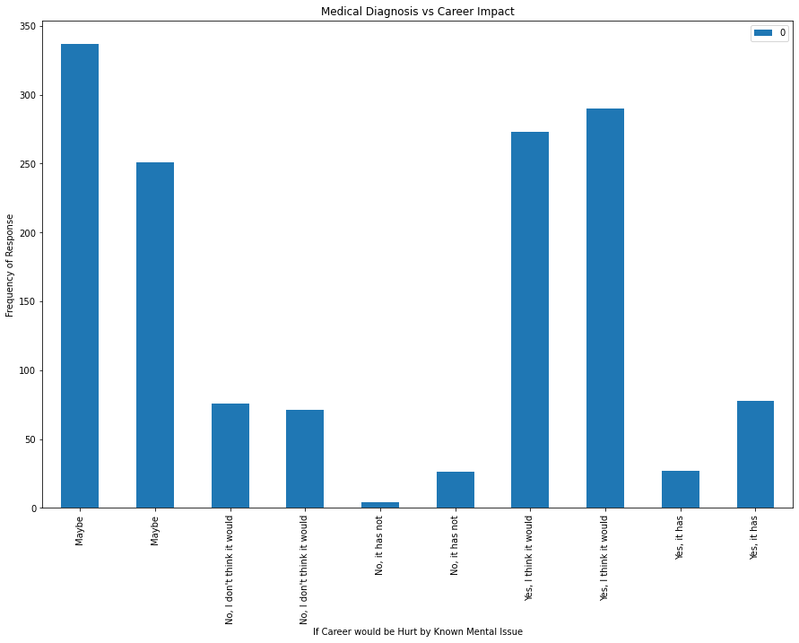

```python
survey_2016.value_counts(["career_impact", "doctor_diagnosis"]).reset_index().sort_values(["career_impact", "doctor_diagnosis"]).set_index('career_impact').plot(kind = 'bar', figsize = (15,10))
plt.title("Medical Diagnosis vs Career Impact")
plt.xlabel("If Career would be Hurt by Known Mental Issue")
plt.ylabel("Frequency of Response")
print(survey_2016.value_counts(["career_impact", "doctor_diagnosis"]).reset_index().sort_values(["career_impact", "doctor_diagnosis"]).set_index('career_impact'))
```

This bar chart shows the perceived perception of if one's career would be impacted negatively because of their known status of having a mental health issue. I compared results of those who have been medically diagnosed versus those who weren't. Those who are not, represent the first bar for each different answer. As we can see, those who were not diagnosed could not concretely say if their career would be affected. Those who were diagnosed had the highest response in saying that Yes, it would hurt their career.

# **2014 vs 2016**

Because these datasets had similar data, I will try to find if there were varying trends based on the two year separation. observed consequence and mental vs physical

```
                   obs_consequence    0
mental_vs_physical
Don't know                      No  525
Don't know                     Yes   51
No                              No  233
No                             Yes  107
Yes                             No  317
Yes                            Yes   26
```

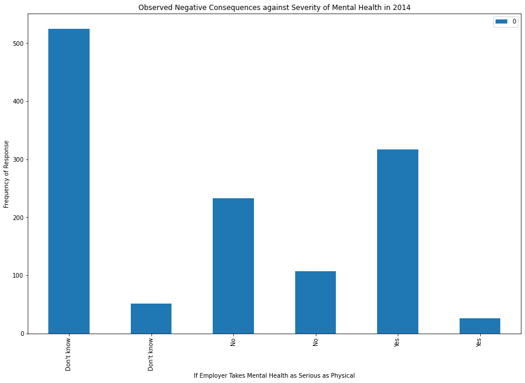

```python
#2014 graph
survey_2014.value_counts(["mental_vs_physical", "obs_consequence"]).reset_index().sort_values(["mental_vs_physical", "obs_consequence"]).set_index('mental_vs_physical').plot(kind = 'bar', figsize = (15,10))
plt.title("Observed Negative Consequences against Severity of Mental Health in 2014")
plt.xlabel("If Employer Takes Mental Health as Serious as Physical")
plt.ylabel("Frequency of Response")
print(survey_2014.value_counts(["mental_vs_physical", "obs_consequence"]).reset_index().sort_values(["mental_vs_physical", "obs_consequence"]).set_index('mental_vs_physical'))
```

```
                   obs_consequence    0
mental_vs_physical
I don't know                    No  462
I don't know                   Yes   31
No                              No  247
No                             Yes   56
Yes                             No  339
Yes                            Yes   11
```

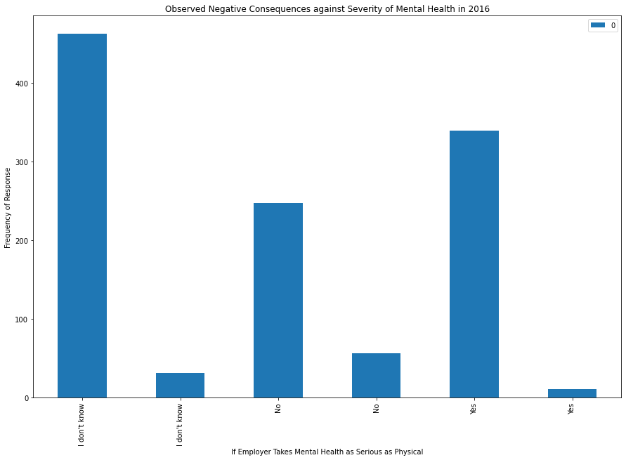

```python
#2016 graph
survey_2016.value_counts(["mental_vs_physical", "obs_consequence"]).reset_index().sort_values(["mental_vs_physical", "obs_consequence"]).set_index('mental_vs_physical').plot(kind = 'bar', figsize = (15,10))
plt.title("Observed Negative Consequences against Severity of Mental Health in 2016")
plt.xlabel("If Employer Takes Mental Health as Serious as Physical")
plt.ylabel("Frequency of Response")
print(survey_2016.value_counts(["mental_vs_physical", "obs_consequence"]).reset_index().sort_values(["mental_vs_physical", "obs_consequence"]).set_index('mental_vs_physical'))
```

In comparison, we see that over the span of two years that employees were still unsure if their employer took mental health and its issues just as serious as physical health. For both years as well, there were more responses for not observing any negative consequences who were open about their mental health issues. In 2016, there was a rise in the number of No responses when employees felt that their employer took mental health just as seriously.

As gathered from my exploratory analysis, discussing mental health is multi-faceted and numerous factors play roles in the overall outlook and attitude towards this topic in the workforce in general.

# Hypothesis Testing

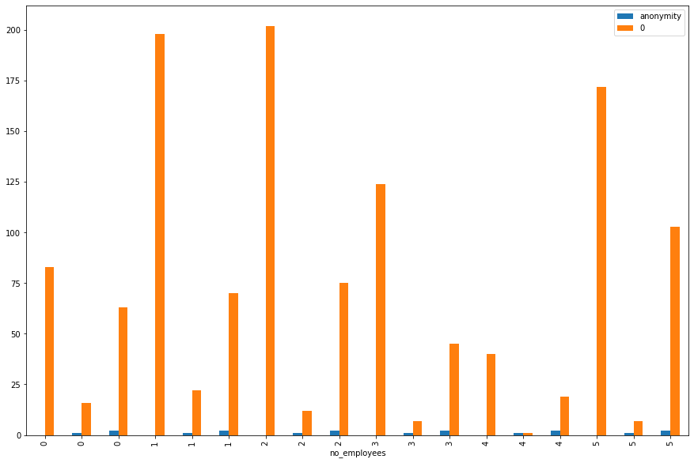

[figure not shown]

```python
#linear regression of size_company and benefits 2014
from sklearn.linear_model import LinearRegression
#rewrite value of size of employees
survey_2014["no_employees"] = np.where((survey_2014["no_employees"] == "1-5"), 0, survey_2014["no_employees"])
survey_2014["no_employees"] = np.where((survey_2014["no_employees"] == "6-25"), 1, survey_2014["no_employees"])
survey_2014["no_employees"] = np.where((survey_2014["no_employees"] == "26-100"), 2, survey_2014["no_employees"])
survey_2014["no_employees"] = np.where((survey_2014["no_employees"] == "100-500"), 3, survey_2014["no_employees"])
survey_2014["no_employees"] = np.where((survey_2014["no_employees"] == "500-1000"), 4, survey_2014["no_employees"])
survey_2014["no_employees"] = np.where((survey_2014["no_employees"] == "More than 1000"), 5, survey_2014["no_employees"])

#rewrite anonymous status
survey_2014["anonymity"] = np.where((survey_2014["anonymity"] == "Don't know"), 0, survey_2014["anonymity"])
survey_2014["anonymity"] = np.where((survey_2014["anonymity"] == "No"), 1, survey_2014["anonymity"])
survey_2014["anonymity"] = np.where((survey_2014["anonymity"] == "Yes"), 2, survey_2014["anonymity"])

survey_2014.value_counts(["no_employees", "anonymity"]).reset_index().sort_values(["no_employees", "anonymity"]).set_index('no_employees').plot(kind = 'bar', figsize = (15,10))
plt.figure(figsize = (10,7))
plt.xlabel("Time (years)")
plt.ylabel("Life Expectancy")
plt.title("Life Expectancy over Time")
```

[output not shown]

# Conclusion and Insights Attained

Even though mental health affects workers in all companies, I decided to dedicate my project to those attitudes that specifically generate within the tech workforce. As a Black woman in STEM, I found personal connections with this topic and hope to find correlations that could be useful to my own experience. Both the stigma and lack of knowledge about mental health contributes to these overall negative perceptions as seen in the frequency of certain responses. I learned about interpretating data even when it does not always present itself in a numerical form. Even if you are not in the tech industry, the information I worked with and how I manipulated it could translate to other datasets in terms of visualizing trends of human social behavior.